# DATA 622 HW4 - Clustering, PCA and SVM

Mael Illien, Dhairav Chhatbar, Santosh Manjrekar

4/12/2021

## Setup

```r
library(skimr)
library(tidyverse)
library(caret) # For featureplot, classification report
library(corrplot) # For correlation matrix
library(AppliedPredictiveModeling)
library(mice) # For data imputation
library(VIM) # For missing data visualization
library(gridExtra) # For grid plots
library(pROC) # For AUC calculations
library(ROCR) # For ROC and AUC plots
library(dendextend) # For dendrograms
library(factoextra) # For PCA plots
library(e1071) # For SVM
```

# ADHD Dataset

This dataset is a compilation of demographic, abuse, drug use, ADHD and mood disorder variarables, where the latter two include individual responses to the these questionnaires: [Adult ADHD Self-Report Scale Symptom Checklis](https://add.org/wp-content/uploads/2015/03/adhd-questionnaire-ASRS111.pdf), [Mood Disorder Questionnaire](https://www.ohsu.edu/sites/default/files/2019-06/cms-quality-bipolar_disorder_mdq_screener.pdf). The rows represent real patient responses.

The first part of this work will make use of unsupervised learning techniques such as Principal Component Analysis (PCA) and clustering. The second part will explore support vector machines in a supervised learning exercised to predict whether an individual has attempted suicide.

```r
adhd_raw <- read.csv('https://raw.githubusercontent.com/maelillien/data622/main/hw4/adhd_data.csv', header = TRUE)
adhd <- adhd_raw
head(adhd)
```

|  | Initial | Age | Sex | Race | ADHD.Q1 | ADHD.Q2 | ADHD.Q3 | ADHD.Q4 | ADHD.Q5 | ADHD.Q6 | ADHD.Q7 | ADHD.Q8 | ADHD.Q9 | ADHD.Q10 | ADHD.Q11 | ADHD.Q12 | ADHD.Q13 | ADHD.Q14 | ADHD.Q15 | ADHD.Q16 | ADHD.Q17 | ADHD.Q18 | ADHD.Total | MD.Q1a | MD.Q1b | MD.Q1c | MD.Q1d | MD.Q1e | MD.Q1f | … |
| --- | --- | --- | --- | --- | --- | --- | --- | --- | --- | --- | --- | --- | --- | --- | --- | --- | --- | --- | --- | --- | --- | --- | --- | --- | --- | --- | --- | --- | --- | --- |
| 1 | JA | 24 | 1 | 1 | 1 | 1 | 4 | 2 | 3 | 1 | 1 | 3 | 2 | 4 | 2 | 4 | 1 | 0 | 3 | 1 | 3 | 4 | 40 | 1 | 1 | 1 | 1 | 0 | 1 | … |
| 2 | LA | 48 | 2 | 1 | 3 | 3 | 4 | 4 | 5 | 2 | 2 | 3 | 2 | 4 | 1 | 4 | 2 | 4 | 4 | 3 | 1 | 4 | 55 | 1 | 1 | 1 | 1 | 1 | 1 | … |
| 3 | MD | 51 | 2 | 1 | 2 | 1 | 2 | 1 | 3 | 3 | 3 | 2 | 0 | 1 | 2 | 0 | 2 | 2 | 3 | 2 | 1 | 1 | 31 | 0 | 0 | 0 | 0 | 1 | 1 | … |
| 4 | RD | 43 | 1 | 1 | 3 | 3 | 2 | 2 | 4 | 3 | 2 | 4 | 4 | 2 | 3 | 1 | 3 | 3 | 1 | 2 | 1 | 2 | 45 | 1 | 1 | 0 | 0 | 1 | 1 | … |
| 5 | RB | 34 | 1 | 1 | 4 | 4 | 2 | 4 | 4 | 2 | 3 | 4 | 4 | 2 | 4 | 1 | 3 | 2 | 1 | 2 | 1 | 1 | 48 | 0 | 1 | 0 | 1 | 0 | 1 | … |
| 6 | SB | 39 | 2 | 1 | 2 | 3 | 1 | 4 | 3 | 2 | 3 | 4 | 4 | 2 | 4 | 2 | 4 | 4 | 3 | 4 | 3 | 3 | 55 | 0 | 1 | 0 | 1 | 1 | 1 | … |

```r
adhd[adhd==''] <- NA
skim(adhd)
```

Data summary

| Name | adhd |
| --- | --- |
| Number of rows | 175 |
| Number of columns | 54 |
| _______________________ |  |
| Column type frequency: |  |
| factor | 1 |
| numeric | 53 |
| ________________________ |  |
| Group variables | None |

**Variable type: factor**

| skim_variable | n_missing | complete_rate | ordered | n_unique | top_counts |
| --- | --- | --- | --- | --- | --- |
| Initial | 0 | 1 | FALSE | 109 | DB: 5, CM: 4, DJ: 4, JM: 4 |

**Variable type: numeric**

| skim_variable | n_missing | complete_rate | mean | sd | p0 | p25 | p50 | p75 | p100 | hist |
| --- | --- | --- | --- | --- | --- | --- | --- | --- | --- | --- |
| Age | 0 | 1.00 | 39.47 | 11.17 | 18 | 29.5 | 42 | 48.0 | 69 | ▆▅▇▅▁ |
| Sex | 0 | 1.00 | 1.43 | 0.50 | 1 | 1.0 | 1 | 2.0 | 2 | ▇▁▁▁▆ |
| Race | 0 | 1.00 | 1.64 | 0.69 | 1 | 1.0 | 2 | 2.0 | 6 | ▇▁▁▁▁ |
| ADHD.Q1 | 0 | 1.00 | 1.70 | 1.29 | 0 | 1.0 | 2 | 3.0 | 4 | ▇▇▇▆▃ |
| ADHD.Q2 | 0 | 1.00 | 1.91 | 1.25 | 0 | 1.0 | 2 | 3.0 | 4 | ▅▇▇▆▅ |
| ADHD.Q3 | 0 | 1.00 | 1.91 | 1.27 | 0 | 1.0 | 2 | 3.0 | 4 | ▅▇▇▆▅ |
| ADHD.Q4 | 0 | 1.00 | 2.10 | 1.34 | 0 | 1.0 | 2 | 3.0 | 4 | ▅▅▇▅▆ |
| ADHD.Q5 | 0 | 1.00 | 2.26 | 1.44 | 0 | 1.0 | 3 | 3.0 | 5 | ▇▅▇▆▁ |
| ADHD.Q6 | 0 | 1.00 | 1.91 | 1.31 | 0 | 1.0 | 2 | 3.0 | 4 | ▆▅▇▇▃ |
| ADHD.Q7 | 0 | 1.00 | 1.83 | 1.19 | 0 | 1.0 | 2 | 3.0 | 4 | ▃▇▇▃▃ |
| ADHD.Q8 | 0 | 1.00 | 2.14 | 1.29 | 0 | 1.0 | 2 | 3.0 | 4 | ▃▇▇▇▆ |
| ADHD.Q9 | 0 | 1.00 | 1.91 | 1.32 | 0 | 1.0 | 2 | 3.0 | 4 | ▆▇▇▇▅ |
| ADHD.Q10 | 0 | 1.00 | 2.12 | 1.23 | 0 | 1.0 | 2 | 3.0 | 4 | ▂▇▇▆▅ |
| ADHD.Q11 | 0 | 1.00 | 2.27 | 1.24 | 0 | 1.0 | 2 | 3.0 | 4 | ▂▆▇▇▆ |
| ADHD.Q12 | 0 | 1.00 | 1.29 | 1.21 | 0 | 0.0 | 1 | 2.0 | 4 | ▇▇▆▂▂ |
| ADHD.Q13 | 0 | 1.00 | 2.37 | 1.23 | 0 | 1.5 | 2 | 3.0 | 4 | ▂▅▇▇▆ |
| ADHD.Q14 | 0 | 1.00 | 2.25 | 1.35 | 0 | 1.0 | 2 | 3.0 | 4 | ▅▅▇▇▆ |
| ADHD.Q15 | 0 | 1.00 | 1.63 | 1.39 | 0 | 0.0 | 1 | 3.0 | 4 | ▇▆▆▅▃ |
| ADHD.Q16 | 0 | 1.00 | 1.70 | 1.38 | 0 | 1.0 | 1 | 3.0 | 4 | ▆▇▆▃▅ |
| ADHD.Q17 | 0 | 1.00 | 1.53 | 1.29 | 0 | 0.0 | 1 | 2.0 | 4 | ▇▇▇▃▃ |
| ADHD.Q18 | 0 | 1.00 | 1.47 | 1.30 | 0 | 0.0 | 1 | 2.0 | 4 | ▇▇▆▃▃ |
| ADHD.Total | 0 | 1.00 | 34.32 | 16.70 | 0 | 21.0 | 33 | 47.5 | 72 | ▃▆▇▆▂ |
| MD.Q1a | 0 | 1.00 | 0.55 | 0.50 | 0 | 0.0 | 1 | 1.0 | 1 | ▆▁▁▁▇ |
| MD.Q1b | 0 | 1.00 | 0.57 | 0.50 | 0 | 0.0 | 1 | 1.0 | 1 | ▆▁▁▁▇ |
| MD.Q1c | 0 | 1.00 | 0.54 | 0.50 | 0 | 0.0 | 1 | 1.0 | 1 | ▇▁▁▁▇ |
| MD.Q1d | 0 | 1.00 | 0.58 | 0.49 | 0 | 0.0 | 1 | 1.0 | 1 | ▆▁▁▁▇ |
| MD.Q1e | 0 | 1.00 | 0.55 | 0.50 | 0 | 0.0 | 1 | 1.0 | 1 | ▆▁▁▁▇ |
| MD.Q1f | 0 | 1.00 | 0.70 | 0.46 | 0 | 0.0 | 1 | 1.0 | 1 | ▃▁▁▁▇ |
| MD.Q1g | 0 | 1.00 | 0.72 | 0.45 | 0 | 0.0 | 1 | 1.0 | 1 | ▃▁▁▁▇ |
| MD.Q1h | 0 | 1.00 | 0.56 | 0.50 | 0 | 0.0 | 1 | 1.0 | 1 | ▆▁▁▁▇ |
| MD.Q1i | 0 | 1.00 | 0.59 | 0.49 | 0 | 0.0 | 1 | 1.0 | 1 | ▆▁▁▁▇ |
| MD.Q1j | 0 | 1.00 | 0.39 | 0.49 | 0 | 0.0 | 0 | 1.0 | 1 | ▇▁▁▁▅ |
| MD.Q1k | 0 | 1.00 | 0.49 | 0.50 | 0 | 0.0 | 0 | 1.0 | 1 | ▇▁▁▁▇ |
| MD.Q1L | 0 | 1.00 | 0.58 | 0.49 | 0 | 0.0 | 1 | 1.0 | 1 | ▆▁▁▁▇ |
| MD.Q1m | 0 | 1.00 | 0.49 | 0.50 | 0 | 0.0 | 0 | 1.0 | 1 | ▇▁▁▁▇ |
| MD.Q2 | 0 | 1.00 | 0.72 | 0.45 | 0 | 0.0 | 1 | 1.0 | 1 | ▃▁▁▁▇ |
| MD.Q3 | 0 | 1.00 | 2.01 | 1.07 | 0 | 1.0 | 2 | 3.0 | 3 | ▂▂▁▅▇ |
| MD.TOTAL | 0 | 1.00 | 10.02 | 4.81 | 0 | 6.5 | 11 | 14.0 | 17 | ▃▃▆▇▇ |
| Alcohol | 4 | 0.98 | 1.35 | 1.39 | 0 | 0.0 | 1 | 3.0 | 3 | ▇▂▁▁▆ |
| THC | 4 | 0.98 | 0.81 | 1.27 | 0 | 0.0 | 0 | 1.5 | 3 | ▇▁▁▁▃ |
| Cocaine | 4 | 0.98 | 1.09 | 1.39 | 0 | 0.0 | 0 | 3.0 | 3 | ▇▁▁▁▅ |
| Stimulants | 4 | 0.98 | 0.12 | 0.53 | 0 | 0.0 | 0 | 0.0 | 3 | ▇▁▁▁▁ |
| Sedative.hypnotics | 4 | 0.98 | 0.12 | 0.54 | 0 | 0.0 | 0 | 0.0 | 3 | ▇▁▁▁▁ |
| Opioids | 4 | 0.98 | 0.39 | 0.99 | 0 | 0.0 | 0 | 0.0 | 3 | ▇▁▁▁▁ |
| Court.order | 5 | 0.97 | 0.09 | 0.28 | 0 | 0.0 | 0 | 0.0 | 1 | ▇▁▁▁▁ |
| Education | 9 | 0.95 | 11.90 | 2.17 | 6 | 11.0 | 12 | 13.0 | 19 | ▁▅▇▂▁ |
| Hx.of.Violence | 11 | 0.94 | 0.24 | 0.43 | 0 | 0.0 | 0 | 0.0 | 1 | ▇▁▁▁▂ |
| Disorderly.Conduct | 11 | 0.94 | 0.73 | 0.45 | 0 | 0.0 | 1 | 1.0 | 1 | ▃▁▁▁▇ |
| Suicide | 13 | 0.93 | 0.30 | 0.46 | 0 | 0.0 | 0 | 1.0 | 1 | ▇▁▁▁▃ |
| Abuse | 14 | 0.92 | 1.33 | 2.12 | 0 | 0.0 | 0 | 2.0 | 7 | ▇▂▁▁▁ |
| Non.subst.Dx | 22 | 0.87 | 0.44 | 0.68 | 0 | 0.0 | 0 | 1.0 | 2 | ▇▁▃▁▁ |
| Subst.Dx | 23 | 0.87 | 1.14 | 0.93 | 0 | 0.0 | 1 | 2.0 | 3 | ▆▇▁▅▂ |
| Psych.meds. | 118 | 0.33 | 0.96 | 0.80 | 0 | 0.0 | 1 | 2.0 | 2 | ▇▁▇▁▆ |

## Data Processing

The dataset is modified to include an `EducationLevel` categorical variable derived from the numerical `Education` variables representing the years of schooling. The `Abuse` column is unfolded into 3 binary variables indicating the occurence of the 3 types of abuse. The original `Abuse` variable is dropped.

We work with a multiple subsets of the data for subsequent parts this report. Some analyses make use of the entire set of questionnaire reponses while others use only the total score.

```r
# Renaming variables
adhd <- rename(adhd, ADHDTotal = ADHD.Total, MDTotal = MD.TOTAL, Sedatives = Sedative.hypnotics, CourtOrder = Court.order,
               Violence = Hx.of.Violence, Conduct = Disorderly.Conduct, NonSubstDX = Non.subst.Dx, SubstDX = Subst.Dx, PsychMeds = Psych.meds.)
# Shift sex variable to 0 and 1
adhd$Sex <- adhd$Sex-1
# Re-coding Education Variable, College = Education > 12, HS = Education > 8 & <= 12, MS = Education <= 8
adhd$EducationLevel <- ifelse(adhd$Education <= 8, 1, ifelse(adhd$Education <= 12 & adhd$Education > 8, 2, ifelse(adhd$Education > 12, 3, 99)))
# Creating new variables based on type of abuse
adhd$AbuseP <- as.numeric(adhd$Abuse == 1 | adhd$Abuse == 4 | adhd$Abuse == 5 | adhd$Abuse == 7)
adhd$AbuseS <- as.numeric(adhd$Abuse == 2 | adhd$Abuse == 4 | adhd$Abuse == 6 | adhd$Abuse == 7)
adhd$AbuseE <- as.numeric(adhd$Abuse == 3 | adhd$Abuse == 5 | adhd$Abuse == 6 | adhd$Abuse == 7)
adhd <- adhd %>% select(-c(Abuse))

# Selecting only variables not containing Qs
adhd.full <- adhd
adhd <- adhd %>% select(c(Age, Sex, Race, ADHDTotal, MDTotal, Alcohol:PsychMeds))

# Set all characters to numeric
adhd <- mutate_all(adhd, function(x) as.numeric(as.character(x)))
```

#### Missing Values

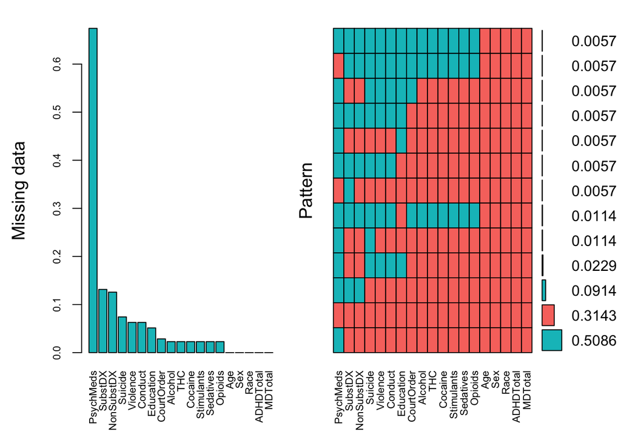

```
##
##  Variables sorted by number of missings:
##    Variable      Count
##   PsychMeds 0.67428571
##     SubstDX 0.13142857
##  NonSubstDX 0.12571429
##     Suicide 0.07428571
##    Violence 0.06285714
##     Conduct 0.06285714
##   Education 0.05142857
##  CourtOrder 0.02857143
##     Alcohol 0.02285714
##         THC 0.02285714
##     Cocaine 0.02285714
##  Stimulants 0.02285714
##   Sedatives 0.02285714
##     Opioids 0.02285714
##         Age 0.00000000
##         Sex 0.00000000
##        Race 0.00000000
##   ADHDTotal 0.00000000
##     MDTotal 0.00000000
```

```r
mice_plot <- aggr(adhd, col=c('#F8766D','#00BFC4'), numbers=TRUE, sortVars=TRUE, labels=names(adhd), cex.axis=.7, gap=3, ylab=c("Missing data","Pattern"))
```

```r
# Discard PsychMeds
adhd.complete <- adhd %>% select(-c(PsychMeds))
# Keep only complete cases
adhd.complete <- adhd.complete[complete.cases(adhd.complete),]
```

## Data Exploration

Data must be scaled

```r
adhd.scaled <- scale(adhd.complete)
```

# Clustering

Clustering refers to a broad set of techniques for finding subgroups, or clusters, in a dataset. We seek to partition observations into distinct groups so that the observations within each group are quite similar to each other, while observations in different groups are quite different from each other. The most popular clustering approaches as K-means and Hierarchical Clustering (HC). While the former requires a pre-specified number of clusters k, the latter does not. HC is bottom-up or agglomerative clustering approach which results in am upside-down tree representation, built from the leaves and combined into clusters up to the trunk. Clusters are identified by horizontal cuts across the dendrogram.

### ADHD Questionnaire

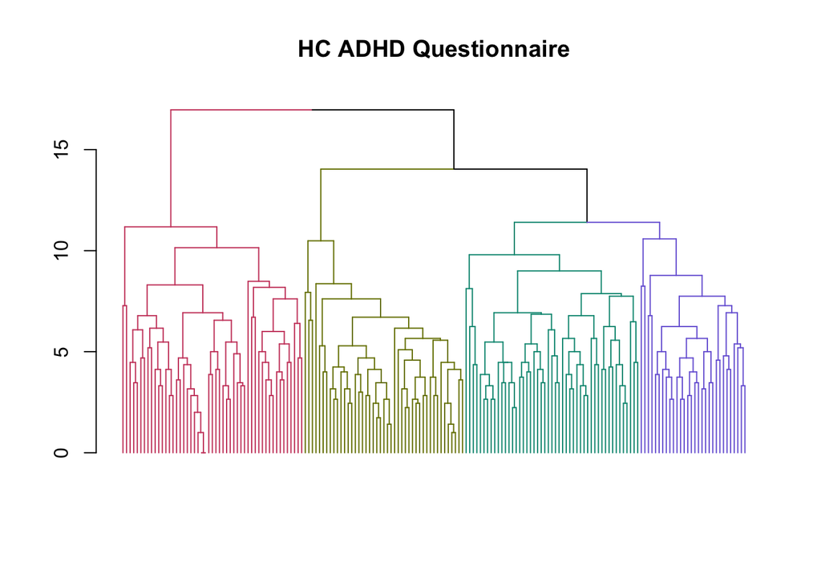

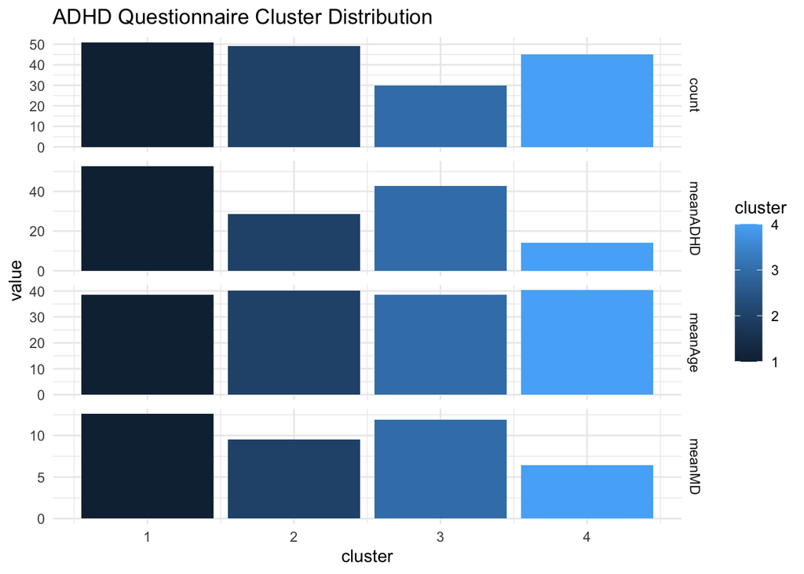

### Complete Dataset

HC, Scaled, Complete Linkage, k=6

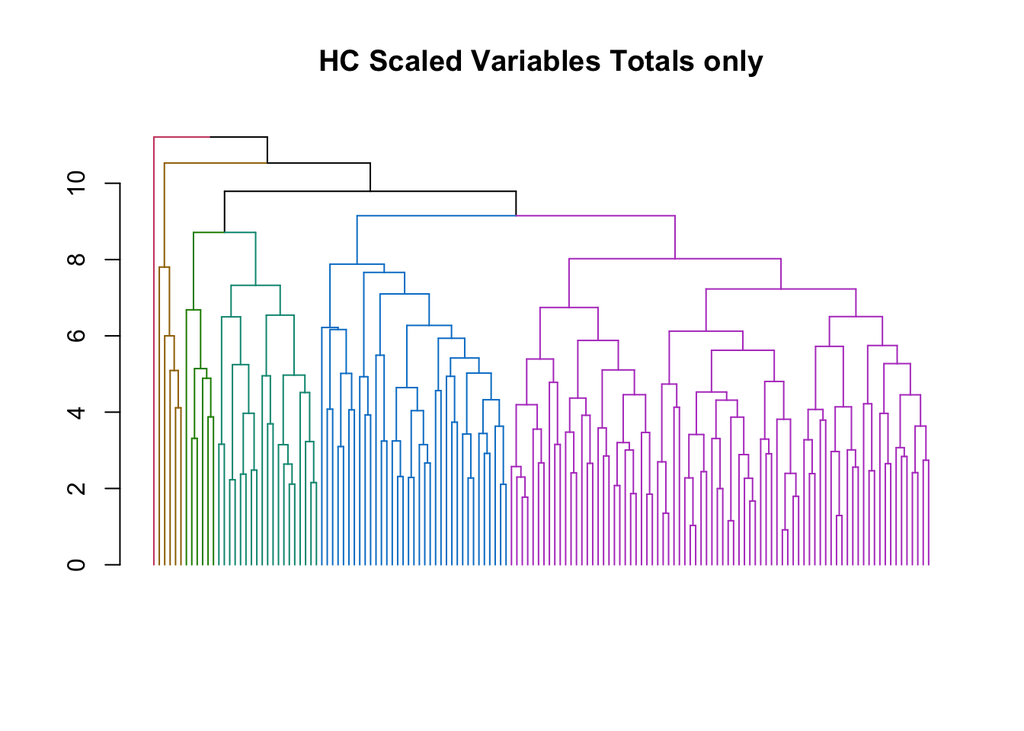

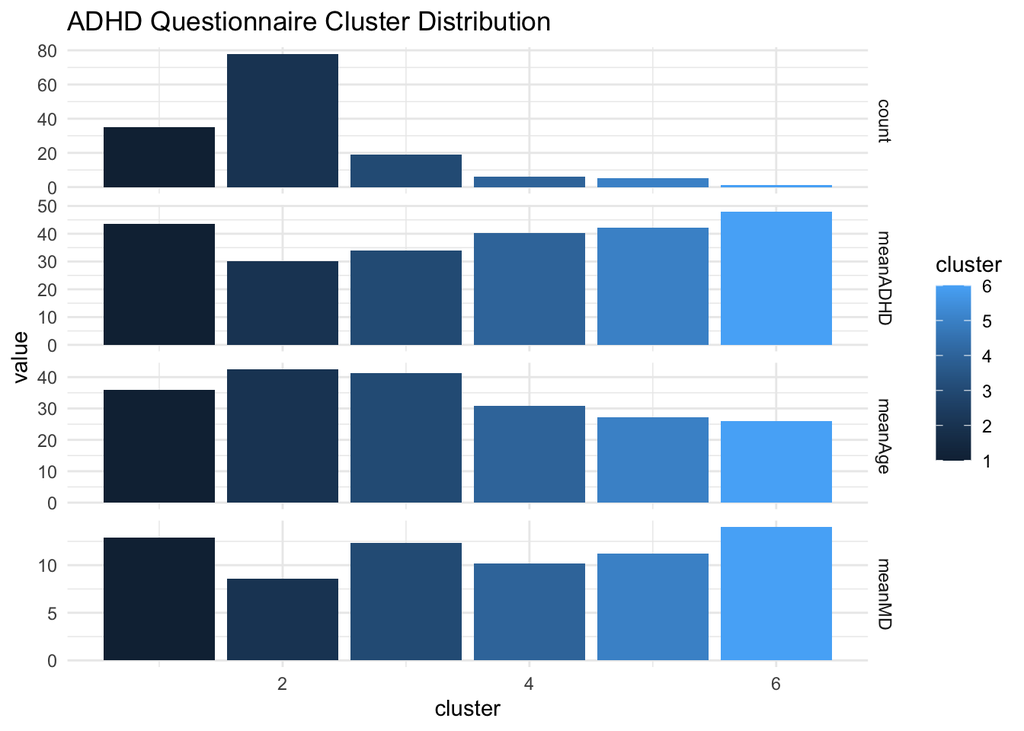

```r
adhd.complete %>%
  mutate(cluster = sub_grp1) %>%
  group_by(cluster) %>%
  summarise(meanAge = mean(Age), meanMD = mean(MDTotal), meanADHD = mean(ADHDTotal), count = n()) %>%
  gather(var,value,meanAge:count) %>%
  ggplot(aes(cluster,value,fill=cluster)) +
  geom_col() + facet_grid(var ~ ., scales="free_y") +
  ggtitle('ADHD Questionnaire Cluster Distribution') +
  theme_minimal()
```

### Comparison

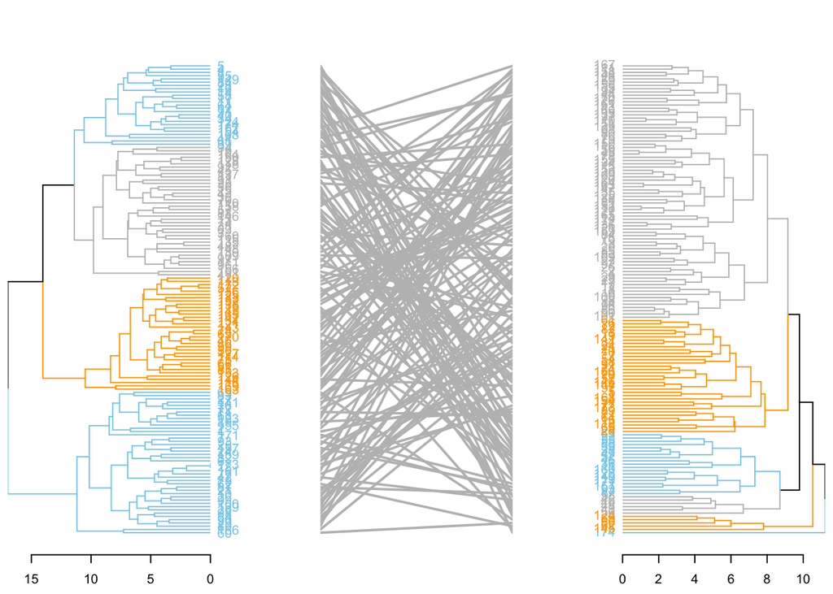

# Principal Component Analysis

PCA is a dimensionality reduction technique in the sense that a dataset is transformed to use p eigenvectors of the covariance matrix instead of the original number of predictors n, where p < n. The number of eigenvectors p is selected by looking at the sorted eigenvalues and determining a threshold percentage of variance explained and the resulting p.

The method seeks to project the data into a lower dimensional space where each axis (or principal component) captures the most variability in the data subject to the condition of being uncorrelated to the other axes. This last condition is important for dimensionality reduction in the sense that large datasets can contain many correlated variables which hold no additional information.

get_eigenvalue(res.pca): Extract the eigenvalues/variances of principal components fviz_eig(res.pca): Visualize the eigenvalues get_pca_ind(res.pca), get_pca_var(res.pca): Extract the results for individuals and variables, respectively. fviz_pca_ind(res.pca), fviz_pca_var(res.pca): Visualize the results individuals and variables, respectively. fviz_pca_biplot(res.pca): Make a biplot of individuals and variables.

An eigenvalue > 1 indicates that PCs account for more variance than accounted by one of the original variables in standardized data. This is commonly used as a cutoff point for which PCs are retained. This holds true only when the data are standardized.

You can also limit the number of component to that number that accounts for a certain fraction of the total variance. For example, if you are satisfied with 70% of the total variance explained then use the number of components to achieve that.

http://www.sthda.com/english/articles/31-principal-component-methods-in-r-practical-guide/112-pca-principal-component-analysis-essentials/

1. PCA with questionnaire responses only (not scaled)

Contributions, Scree

Eigenvectors and variable plot, Scree

### ADHD Questionnaire

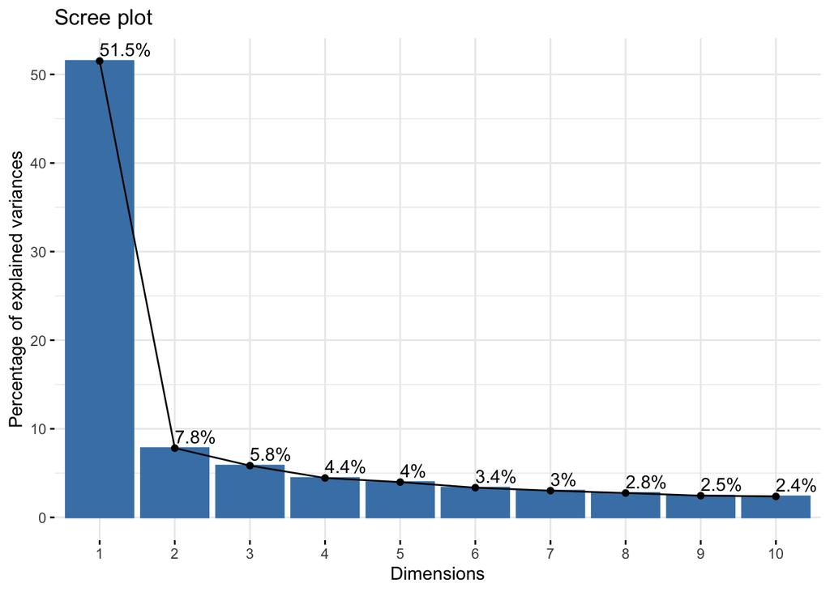

```r
pca_data.adhd <- adhd.full %>% select(ADHD.Q1:ADHD.Q18)
res.pca.adhd <- prcomp(pca_data.adhd, scale = FALSE)
res.var <- get_pca_var(res.pca.adhd)
fviz_eig(res.pca.adhd, addlabels = TRUE)
```

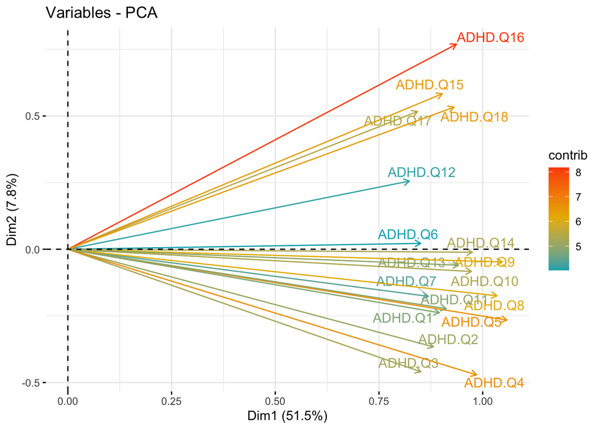

```r
fviz_pca_var(res.pca.adhd,
             col.var = "contrib", # Color by contributions to the PC
             gradient.cols = c("#00AFBB", "#E7B800", "#FC4E07"),
             repel = TRUE     # Avoid text overlapping
             )
```

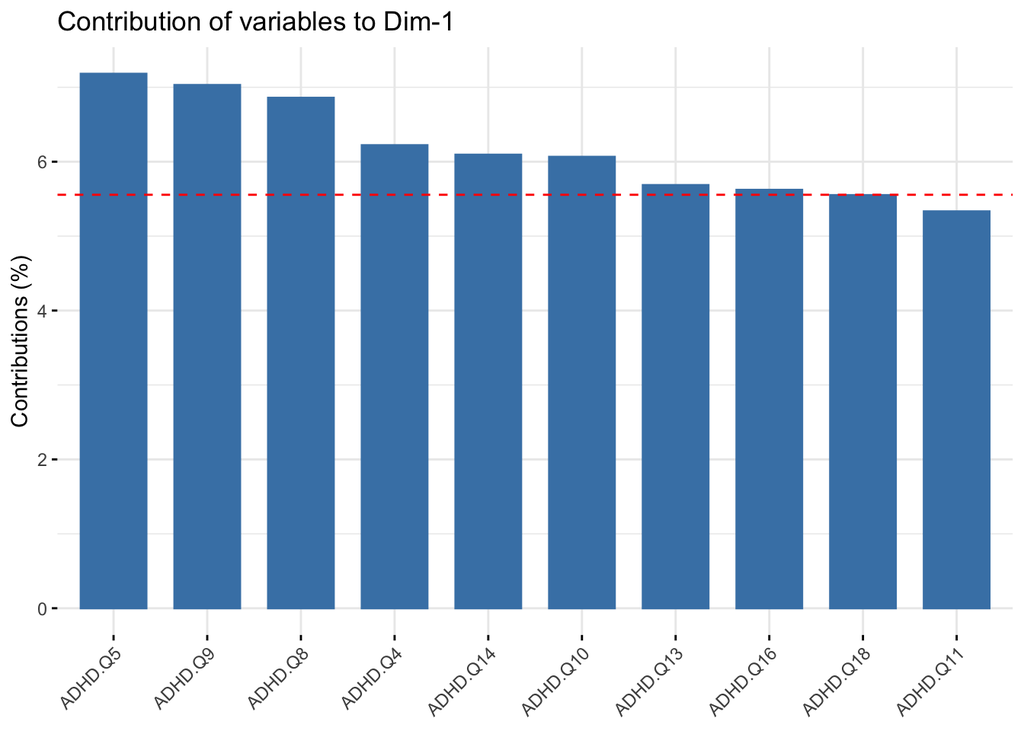

```r
# Contributions of variables to PC1
fviz_contrib(res.pca.adhd, choice = "var", axes = 1, top = 10)
```

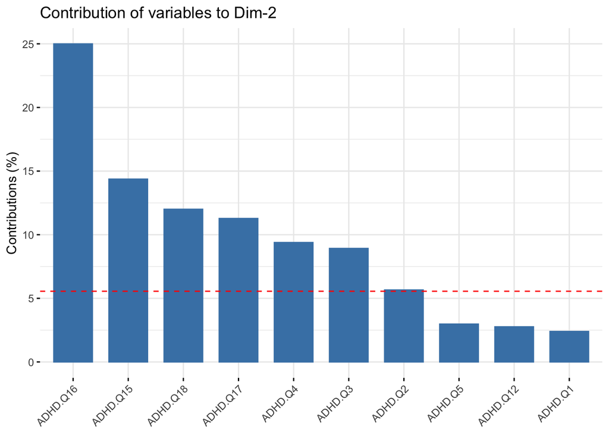

```r
# Contributions of variables to PC2
fviz_contrib(res.pca.adhd, choice = "var", axes = 2, top = 10)
```

### Complete Dataset

```r
data.pca <- adhd.complete
res.pca <- prcomp(data.pca, scale = TRUE)
```

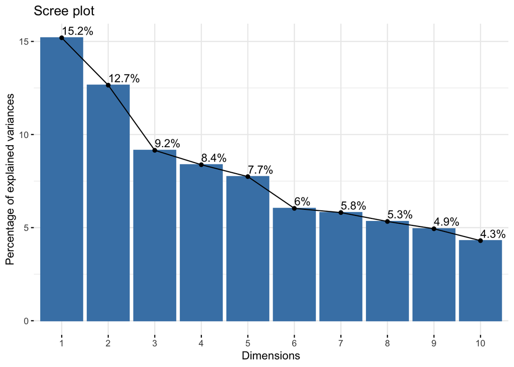

```r
fviz_eig(res.pca, addlabels = TRUE)
```

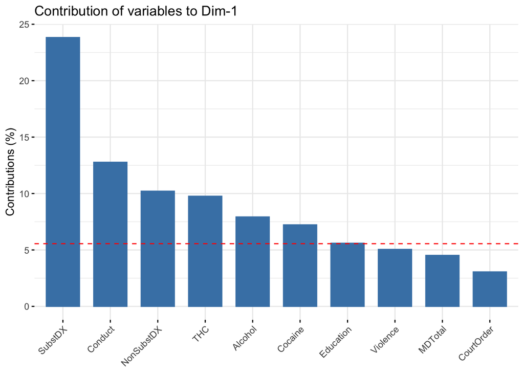

```r
fviz_contrib(res.pca, choice = "var", axes = 1, top = 10)
```

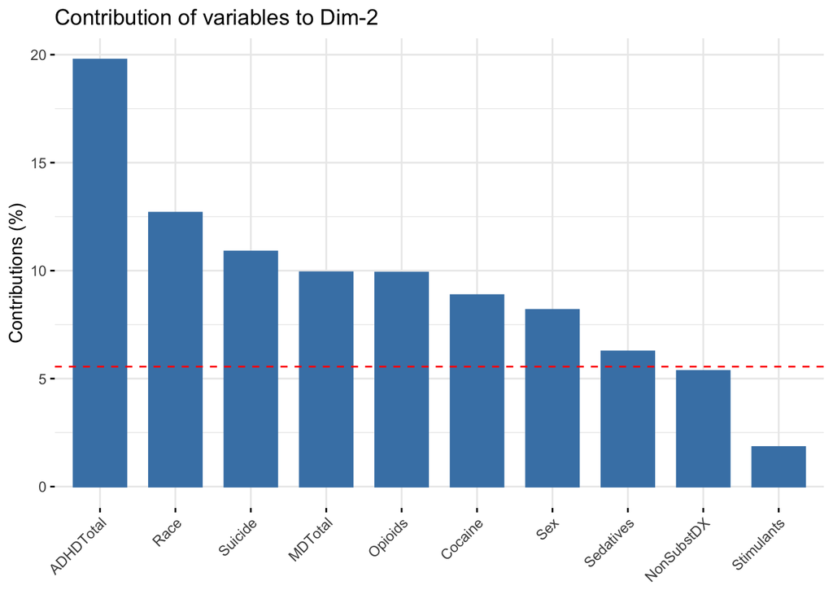

```r
fviz_contrib(res.pca, choice = "var", axes = 2, top = 10)
```

Variable correlation plot and quality of representation/contribution

Positively correlated variables are grouped together. Negatively correlated variables are positioned on opposite sides of the plot origin (opposed quadrants). The distance between variables and the origin measures the quality of the variables on the factor map. Variables that are away from the origin are well represented on the factor map.

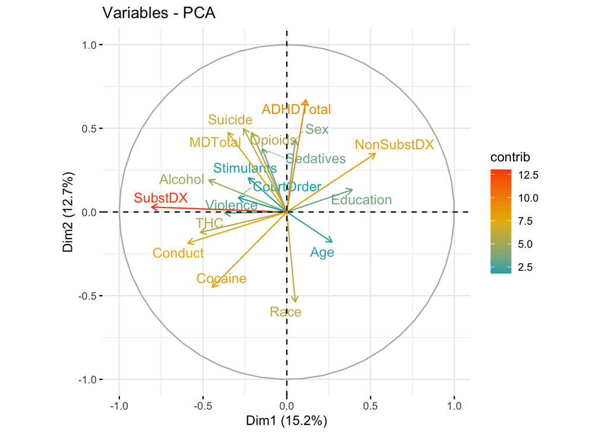

```r
fviz_pca_var(res.pca,
             col.var = "contrib", # Color by contributions to the PC
             gradient.cols = c("#00AFBB", "#E7B800", "#FC4E07"),
             repel = TRUE     # Avoid text overlapping
             )
```

# SVM

## SVM - Via Dataset

```r
adhd.complete2 <- adhd.complete
adhd.complete2$Suicide <- as.factor(adhd.complete2$Suicide)

set.seed(55)
trainIndex <- createDataPartition(adhd.complete2$Suicide, p = .8, list = FALSE, times = 1)
adhd.training <- adhd.complete2[ trainIndex,]
adhd.testing  <- adhd.complete2[-trainIndex,]
```

```r
svm_m <- tune(svm, Suicide ~., data = adhd.training, ranges=list(
  kernel=c("linear", "polynomial", "radial", "sigmoid"),
  cost=2^(2:8),
  epsilon = seq(0,1,0.1)))
summary(svm_m)
```

```
##
## Parameter tuning of 'svm':
##
## - sampling method: 10-fold cross validation
##
## - best parameters:
##  kernel cost epsilon
##  linear    4       0
##
## - best performance: 0.2931818
##
## - Detailed performance results:
##         kernel cost epsilon     error dispersion
## 1       linear    4     0.0 0.2931818 0.14875645
## 2   polynomial    4     0.0 0.3696970 0.14310854
```

[output cut: 306 more lines]

```r
svm_m_best <- svm_m$best.model
svm_pred <- predict(svm_m_best, newdata = adhd.testing, type="class")
svm_cm <- confusionMatrix(svm_pred, adhd.testing$Suicide)
svm_cm$table
```

```
##           Reference
## Prediction  0  1
##          0 16  3
##          1  3  6
```

```r
sum(diag(svm_cm$table))/sum(svm_cm$table)
```

```
## [1] 0.7857143
```

## SVM - Via PCA

```r
adhd_raw2 <- adhd_raw %>% select(-MD.TOTAL, -ADHD.Total, -Initial, -Psych.meds.)
adhd_raw2 <- adhd_raw2[complete.cases(adhd_raw2), ]
adhd_raw2$Suicide <- as.factor(adhd_raw2$Suicide)
set.seed(55)
trainIndex <- createDataPartition(adhd_raw2$Suicide, p = .8, list = FALSE, times = 1)
adhd_pca.training <- adhd_raw2[ trainIndex,]
adhd_pca.testing  <- adhd_raw2[-trainIndex,]
```

```r
svm_pca_m <- prcomp(select(adhd_pca.training, -Suicide), center = TRUE, scale = TRUE)
summary(svm_pca_m)
```

```
## Importance of components:
##                           PC1    PC2     PC3     PC4     PC5     PC6     PC7
## Standard deviation     3.4453 2.2528 1.55906 1.37007 1.34635 1.28866 1.27728
## Proportion of Variance 0.2422 0.1036 0.04961 0.03831 0.03699 0.03389 0.03329
## Cumulative Proportion  0.2422 0.3458 0.39543 0.43374 0.47073 0.50462 0.53792
##                            PC8     PC9    PC10    PC11    PC12    PC13    PC14
## Standard deviation     1.22380 1.19497 1.16886 1.08459 1.05487 1.04846 1.03414
## Proportion of Variance 0.03057 0.02914 0.02788 0.02401 0.02271 0.02243 0.02183
## Cumulative Proportion  0.56848 0.59762 0.62551 0.64951 0.67222 0.69466 0.71648
##                           PC15    PC16    PC17    PC18    PC19   PC20   PC21
## Standard deviation     1.00751 0.96060 0.95823 0.91873 0.87611 0.8400 0.8340
## Proportion of Variance 0.02072 0.01883 0.01874 0.01723 0.01566 0.0144 0.0142
## Cumulative Proportion  0.73720 0.75603 0.77477 0.79199 0.80766 0.8221 0.8363
##                           PC22    PC23    PC24    PC25    PC26    PC27    PC28
## Standard deviation     0.81062 0.78359 0.76540 0.69345 0.67529 0.64590 0.63526
## Proportion of Variance 0.01341 0.01253 0.01196 0.00981 0.00931 0.00851 0.00824
## Cumulative Proportion  0.84966 0.86219 0.87415 0.88396 0.89327 0.90178 0.91002
##                           PC29    PC30    PC31    PC32    PC33    PC34    PC35
## Standard deviation     0.62827 0.60068 0.59058 0.57195 0.56669 0.54155 0.52992
## Proportion of Variance 0.00806 0.00736 0.00712 0.00668 0.00655 0.00599 0.00573
## Cumulative Proportion  0.91808 0.92544 0.93256 0.93923 0.94579 0.95177 0.95750
##                          PC36    PC37    PC38    PC39    PC40    PC41    PC42
## Standard deviation     0.5050 0.48908 0.47771 0.44431 0.42168 0.39567 0.37971
## Proportion of Variance 0.0052 0.00488 0.00466 0.00403 0.00363 0.00319 0.00294
## Cumulative Proportion  0.9627 0.96759 0.97225 0.97628 0.97990 0.98310 0.98604
##                           PC43    PC44    PC45    PC46   PC47    PC48    PC49
## Standard deviation     0.36480 0.34923 0.32573 0.31662 0.2968 0.27565 0.24184
## Proportion of Variance 0.00272 0.00249 0.00217 0.00205 0.0018 0.00155 0.00119
## Cumulative Proportion  0.98876 0.99125 0.99341 0.99546 0.9973 0.99881 1.00000
```

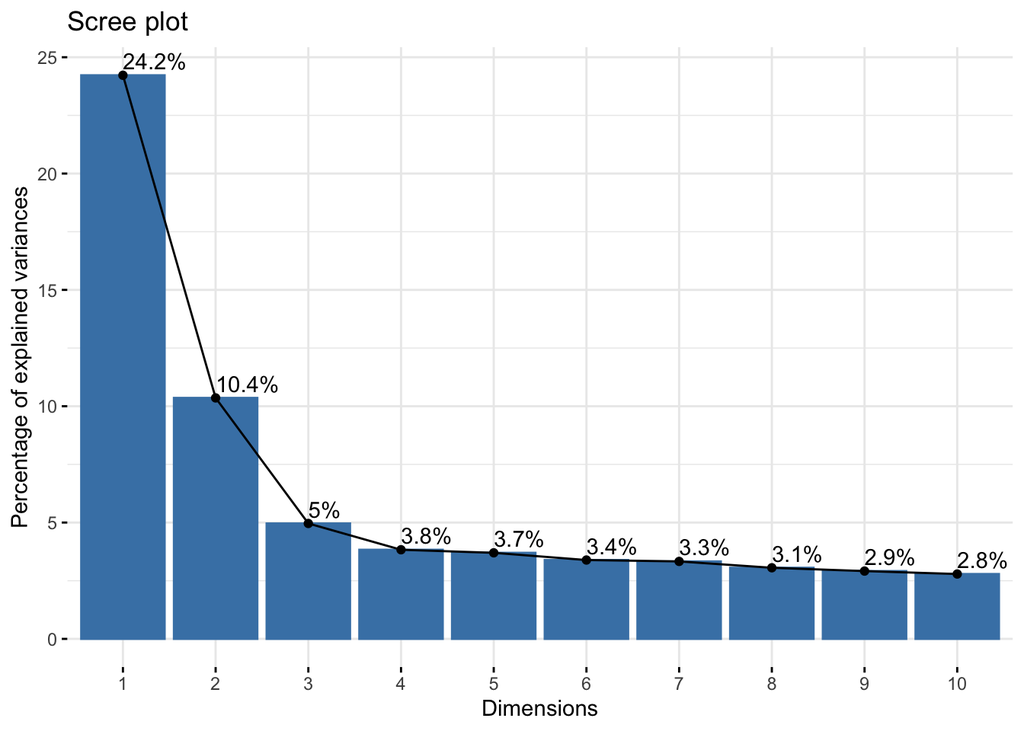

```r
fviz_eig(svm_pca_m, addlabels = T)
```

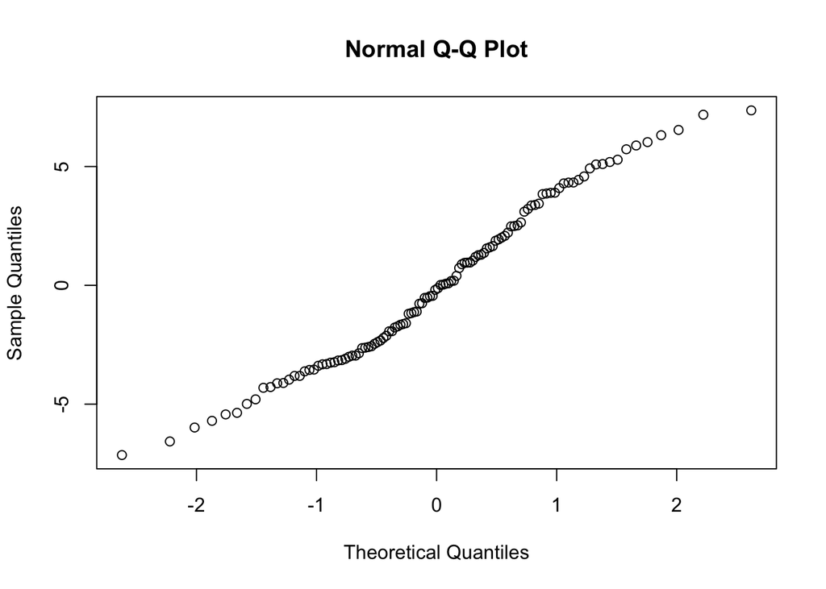

```r
#check for normality and outliers, since we scaled the the original features, the qqplot should be normal as well
qqnorm(svm_pca_m[["x"]][,1])
```

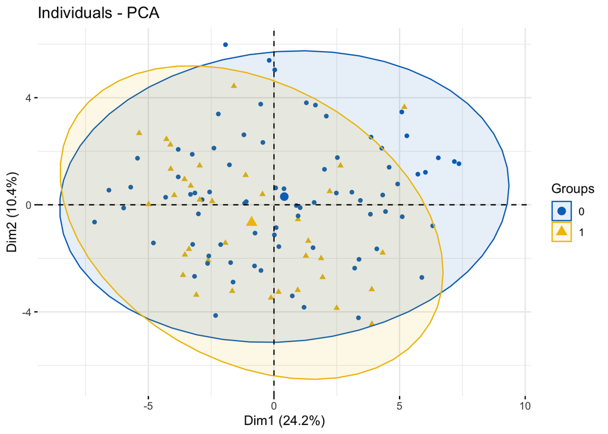

```r
fviz_pca_ind(svm_pca_m, label="none",
             habillage = adhd_pca.training$Suicide,
             addEllipses = TRUE, palette = "jco")
```

```r
#Kaiser rule: select PCs with eigenvalues of at least 1
reduced_dim <- get_eigenvalue(svm_pca_m) %>% filter(eigenvalue > 1)
reduced_dim
```

|  | eigenvalue | variance.percent | cumulative.variance.percent |
| --- | --- | --- | --- |
| Dim.1 | 11.870317 | 24.225136 | 24.22514 |
| Dim.2 | 5.075139 | 10.357427 | 34.58256 |
| Dim.3 | 2.430668 | 4.960547 | 39.54311 |
| Dim.4 | 1.877094 | 3.830805 | 43.37391 |
| Dim.5 | 1.812669 | 3.699325 | 47.07324 |
| Dim.6 | 1.660638 | 3.389058 | 50.46230 |
| Dim.7 | 1.631439 | 3.329467 | 53.79176 |
| Dim.8 | 1.497689 | 3.056508 | 56.84827 |
| Dim.9 | 1.427951 | 2.914186 | 59.76246 |
| Dim.10 | 1.366230 | 2.788225 | 62.55068 |

[output cut: 5 more lines]

```r
adhd_pca.training_reduced <- cbind(as.data.frame(svm_pca_m$x[,c(1:nrow(reduced_dim))]), Suicide = adhd_pca.training$Suicide)
head(adhd_pca.training_reduced)
```

|  | PC1 | PC2 | PC3 | PC4 | PC5 | PC6 | PC7 | PC8 | PC9 | PC10 | PC11 | PC12 | PC13 | PC14 | PC15 | Suicide |
| --- | --- | --- | --- | --- | --- | --- | --- | --- | --- | --- | --- | --- | --- | --- | --- | --- |
| 1 | -1.934240 | -1.4270703 | -1.7890225 | 1.5153500 | 0.4821013 | 1.4365657 | 1.6533648 | -1.82063887 | -0.6386133 | 3.1084264 | -2.24536935 | 2.4061745 | -3.3815341 | 1.16925794 | -0.2913100 | 1 |
| 2 | -4.110553 | 1.3396790 | -1.0603377 | 0.3982512 | 1.4351276 | -0.6266736 | 0.1748660 | -1.02435909 | -1.4890972 | -0.8181185 | -0.53853661 | -0.6647474 | -0.8674569 | 1.80472952 | -0.5534886 | 1 |
| 3 | 1.288758 | 3.8111669 | 0.4201465 | -0.9908338 | 2.0155814 | -0.7053876 | 1.9901513 | -0.06593853 | -2.0350223 | -1.7073882 | 1.03189195 | -0.1540520 | -0.2411550 | 1.04787192 | -1.2833753 | 0 |
| 4 | -2.957243 | 1.4644406 | 0.7750091 | 0.1075158 | 1.0727986 | -1.0481998 | 1.4245642 | -0.32371489 | -0.7686236 | 0.4564773 | 0.04698456 | -2.2648387 | -0.1149778 | 1.07796255 | -0.6187747 | 1 |
| 6 | -3.968294 | 0.3577363 | -0.4682686 | 0.5145387 | 0.6419575 | 1.0952504 | 0.8537101 | -0.52307290 | 0.3863449 | -1.7992537 | 0.73237577 | 0.8588974 | 0.4478387 | -0.71466998 | 0.3696742 | 1 |
| 7 | -3.254587 | 1.8870629 | 3.9934676 | -0.2958127 | -1.1774556 | 0.9938023 | 0.3300327 | -0.57875307 | -2.1763679 | -2.2955220 | -0.84363077 | -0.5880867 | -0.4873818 | 0.07948545 | -0.9533343 | 0 |

```r
#rotate the test data using the predict function in the same rotation as the training data
# rotation done with PC that have eigenvalue < 1 dropped
adhd_pca.testing_reduced <- cbind(as.data.frame(predict(svm_pca_m, newdata = select(adhd_pca.testing, -Suicide))[,c(1:nrow(reduced_dim))]),Suicide = adhd_pca.testing$Suicide)
head(adhd_pca.testing_reduced)
```

|  | PC1 | PC2 | PC3 | PC4 | PC5 | PC6 | PC7 | PC8 | PC9 | PC10 | PC11 | PC12 | PC13 | PC14 | PC15 | Suicide |
| --- | --- | --- | --- | --- | --- | --- | --- | --- | --- | --- | --- | --- | --- | --- | --- | --- |
| 5 | -2.0092936 | 3.088900 | 1.5576435 | 1.2788010 | -0.4283571 | 0.3976225 | 3.0495922 | 0.03376549 | -0.04956085 | 2.0503253 | 0.40906505 | 1.1280129 | -1.7731515 | -0.09090612 | 2.0924024 | 1 |
| 9 | -4.0932096 | 1.756220 | 1.6310338 | 1.0964527 | -0.7249974 | -1.1624742 | 1.1277947 | -0.07804324 | 0.34529275 | -1.2690649 | 0.13352413 | 0.6554208 | 0.1314500 | 1.07649184 | -0.4512868 | 0 |
| 12 | 1.9257534 | 5.115690 | 0.6967141 | -0.1546008 | -0.3512242 | -0.2199466 | 0.1339397 | -1.97237676 | -1.54655923 | 0.1006677 | 0.08826705 | -0.8117507 | -0.3560578 | -0.37087028 | -0.1470289 | 0 |
| 15 | 0.8703954 | -1.990586 | 1.5088167 | 2.1020417 | 0.2854532 | 1.7208141 | 1.7247455 | -0.93534466 | -1.45743353 | 0.9373562 | -0.87095713 | 1.3998813 | -0.5738588 | -1.10764136 | 0.5642853 | 0 |
| 16 | -0.8008403 | 4.467803 | 1.3170561 | 1.8259777 | 3.0312737 | -0.0931679 | -0.1851785 | -0.43841006 | -0.01310095 | -0.8287430 | -0.08132138 | -0.7734507 | 0.9672249 | 0.26308964 | 1.7505942 | 0 |
| 25 | -4.3180773 | -0.334913 | -0.1495675 | -0.2336110 | 0.7913202 | -0.4678702 | 1.6088661 | -1.50135036 | -1.71867645 | -1.8882727 | 0.30996790 | 0.4392534 | 0.7445863 | -0.27811655 | -0.9126070 | 0 |

```r
svm_pca_m <- tune(svm, Suicide ~., data = adhd_pca.training_reduced, ranges=list(
  kernel=c("linear", "polynomial", "radial", "sigmoid"),
  cost=2^(2:8),
  epsilon = seq(0,1,0.1)))
summary(svm_pca_m)
```

```
##
## Parameter tuning of 'svm':
##
## - sampling method: 10-fold cross validation
##
## - best parameters:
##   kernel cost epsilon
##  sigmoid    4       0
##
## - best performance: 0.2628788
##
## - Detailed performance results:
##         kernel cost epsilon     error dispersion
## 1       linear    4     0.0 0.3318182 0.08396607
## 2   polynomial    4     0.0 0.2878788 0.09360481
```

[output cut: 306 more lines]

```r
svm_pca_m_best <- svm_pca_m$best.model
svm_pca_pred <- predict(svm_pca_m_best, newdata = adhd_pca.testing_reduced, type="class")
svm_pca_cm <- confusionMatrix(svm_pca_pred, adhd_pca.testing_reduced$Suicide)
svm_pca_cm$table
```

```
##           Reference
## Prediction  0  1
##          0 14  7
##          1  5  2
```

```r
sum(diag(svm_pca_cm$table))/sum(svm_pca_cm$table)
```

```
## [1] 0.5714286
```